# CourseraMLProject

BDerstine

12/2/2017

# Background

(Copied from the Course Project assignment website)

Using devices such as Jawbone Up, Nike FuelBand, and Fitbit it is now possible to collect a large amount of data about personal activity relatively inexpensively. These type of devices are part of the quantified self movement – a group of enthusiasts who take measurements about themselves regularly to improve their health, to find patterns in their behavior, or because they are tech geeks. One thing that people regularly do is quantify how much of a particular activity they do, but they rarely quantify how well they do it. In this project, (my) goal will be to use data from accelerometers on the belt, forearm, arm, and dumbell of 6 participants to predict the manner in which they did the exercise. They were asked to perform barbell lifts correctly and incorrectly in 5 different ways.

Six young health participants were asked to perform one set of 10 repetitions of the Unilateral Dumbbell Biceps Curl in five different fashions: * exactly according to the specification (Class A),  
* throwing the elbows to the front (Class B),  
* lifting the dumbbell only halfway (Class C),  
* lowering the dumbbell only halfway (Class D) and  
* throwing the hips to the front (Class E).

More information is available from the website here: http://groupware.les.inf.puc-rio.br/har#weight_lifting_exercises.

# Data

The training data for this project are available here: https://d396qusza40orc.cloudfront.net/predmachlearn/pml-training.csv

The test data are available here: https://d396qusza40orc.cloudfront.net/predmachlearn/pml-testing.csv

The data for this project come from this source: http://groupware.les.inf.puc-rio.br/har. (Thanks!)

An example of what the data look like:

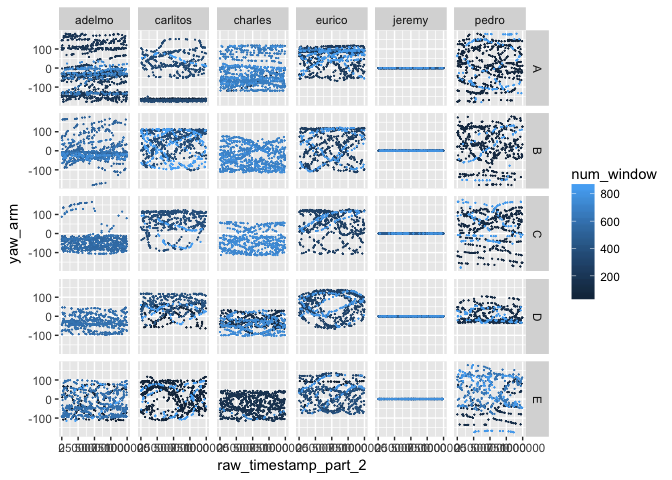

There are some highly correlated variables in the data:

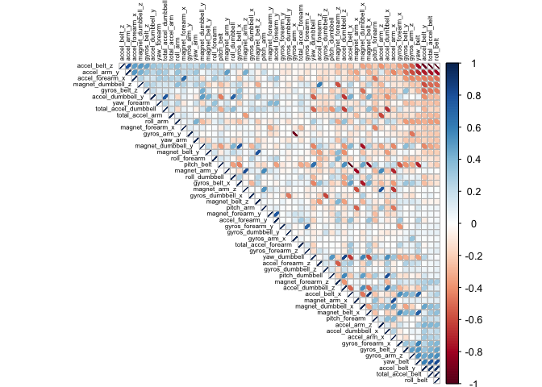

# Methods

The goal of (my) project is to predict the manner in which the participants did the exercise. This is the “classe” variable in the training set. Information about the other variables collected is available here: http://groupware.les.inf.puc-rio.br/public/papers/2013.Velloso.QAR-WLE.pdf

# Results

My final model had an Accuracy of 99% in the training and testing sets that I created, so I expect the out of sample Accuracy to be 99% as well (1% error rate).

List of variable importance in the final model:

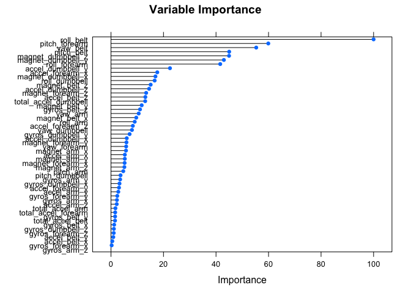

### Training Set:

Model accuracy summaries (training set, each resample, and CV confusion matrix) below:

```
## Random Forest
##
## 14718 samples
##    52 predictor
##     5 classes: 'A', 'B', 'C', 'D', 'E'
##
## No pre-processing
## Resampling: Cross-Validated (5 fold)
## Summary of sample sizes: 11774, 11774, 11775, 11775, 11774
## Resampling results across tuning parameters:
##
##   mtry  Accuracy   Kappa
##    2    0.9908954  0.9884820
##   27    0.9925941  0.9906320
##   52    0.9885175  0.9854743
##
## Accuracy was used to select the optimal model using the largest value.
## The final value used for the model was mtry = 27.
```

```
##    Accuracy     Kappa Resample
## 1 0.9918478 0.9896891    Fold1
## 2 0.9952429 0.9939824    Fold3
## 3 0.9925272 0.9905477    Fold2
## 4 0.9928668 0.9909745    Fold5
## 5 0.9904859 0.9879664    Fold4
```

```
## Cross-Validated (5 fold) Confusion Matrix
##
## (entries are percentual average cell counts across resamples)
##
##           Reference
## Prediction    A    B    C    D    E
##          A 28.4  0.1  0.0  0.0  0.0
##          B  0.0 19.1  0.1  0.0  0.0
##          C  0.0  0.1 17.3  0.2  0.0
##          D  0.0  0.0  0.1 16.2  0.1
##          E  0.0  0.0  0.0  0.0 18.3
##
##  Accuracy (average) : 0.9926
```

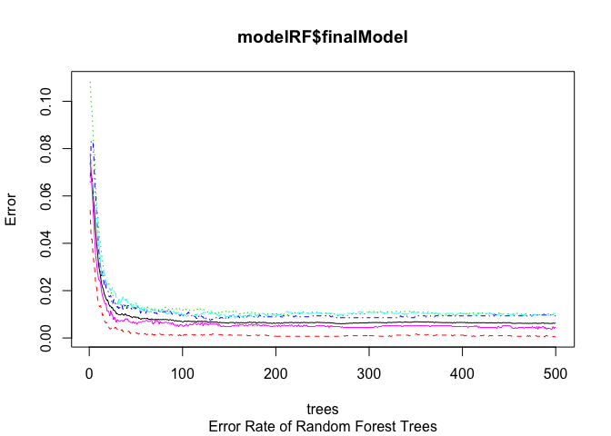

### Testing Set:

And on the testing (OOB) set:

```
## Confusion Matrix and Statistics
##
##           Reference
## Prediction    A    B    C    D    E
##          A 1392    2    0    0    1
##          B   11  932    6    0    0
##          C    0    2  847    6    0
##          D    0    0    9  795    0
##          E    0    1    1    2  897
##
## Overall Statistics
##
##                Accuracy : 0.9916
##                  95% CI : (0.9887, 0.994)
##     No Information Rate : 0.2861
##     P-Value [Acc > NIR] : < 2.2e-16
##
##                   Kappa : 0.9894
##  Mcnemar's Test P-Value : NA
##
## Statistics by Class:
##
##                      Class: A Class: B Class: C Class: D Class: E
## Sensitivity            0.9922   0.9947   0.9815   0.9900   0.9989
## Specificity            0.9991   0.9957   0.9980   0.9978   0.9990
## Pos Pred Value         0.9978   0.9821   0.9906   0.9888   0.9956
## Neg Pred Value         0.9969   0.9987   0.9960   0.9980   0.9998
## Prevalence             0.2861   0.1911   0.1760   0.1637   0.1831
## Detection Rate         0.2838   0.1900   0.1727   0.1621   0.1829
## Detection Prevalence   0.2845   0.1935   0.1743   0.1639   0.1837
## Balanced Accuracy      0.9957   0.9952   0.9897   0.9939   0.9989
```

# Discussion

Also Len’s (Course Mentor) write-up here was quite helpful in implementing parallel processing to optimize the use of my computer’s cores and minimize processing time: https://github.com/lgreski/datasciencectacontent/blob/master/markdown/pml-randomForestPerformance.md was quite helpful.